# Integration test for MRSea 2d salsa no 1d smooth, no other variables, no panels, no interactions

LAS Scott-Hayward, C Fell

2020-08-16

## Introduction

This is the fourth in a series of tests that can be used to check changes to the MRSea package do not break previously working elements. They replicate the case study in the vignette but broken down into chunks. This fourth one checks the 2D salsa functions with just the 2d smooth and no other variables, no panel structure and no interactions.

```r
count.data <- read.csv("1.count.data.csv")
data <- count.data
data$response <- round(data$NHAT)
data$blockid <- paste(data$transect.id, data$season, data$impact,sep = "")
attach(data)
```

## Set up

```r
initialModel <- glm(response ~ 1 + offset(log(area)),
  family = "quasipoisson", data = data)
```

## Selection of flexibility for 2D smooth term

Create a grid of knots that will be used as possible knot locations.

```r
set.seed(1234)
knotgrid <- getKnotgrid(coordData = cbind(data$x.pos, data$y.pos), numKnots = 300)
```

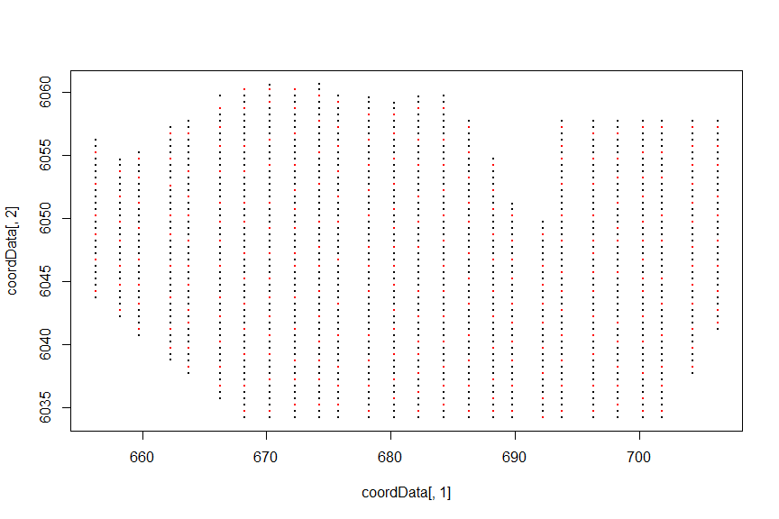

Sum of knotgrid: 2018630 this should be 2018630.

Calculate distance matrix

Sum of datadist: 8224.849 this should be 8224.849.

Sum of knotdist: 1775357 this should be 1775357.

Salsa 2D parameters

```r
salsa2dlist<-list(
  fitnessMeasure = 'cv.gamMRSea',
  knotgrid = knotgrid,
  startKnots=30,
  minKnots=4,
  maxKnots=40,
  gap=0,
  cv.opts=list(cv.gamMRSea.seed=1, K=5)
)
```

Run SALSA2D to find the appropriate number and location of knots for the 2D smooth term of `x.pos` and `y.pos`.

```r
start_time <- Sys.time()
salsa2dOutput<-runSALSA2D(initialModel, salsa2dlist,
  d2k=distMats$dataDist, k2k=distMats$knotDist, suppress.printout=TRUE)
total_time <- Sys.time() - start_time
```

## Predictions compared to original

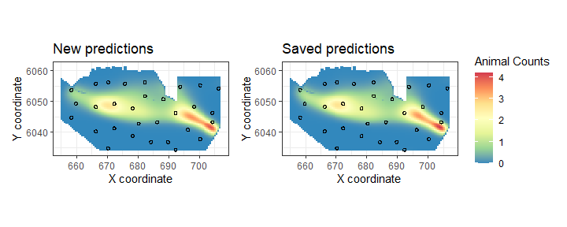

```
[1] "warning: no offset included as link response specified"
```

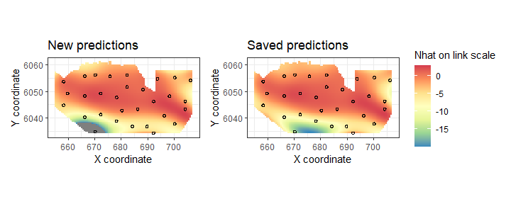

Sum of all predictions on response scale: 2173.877 this should be 2174.191.

Sum of all predictions on link scale: -12365.84 this should be -11041.15.

Time for training: 21.6 Original time: 59.5.

Number of model fits: 757 Original model fits: 994

Coefficients from new model

|  | Estimate | Std. Error | Robust S.E. | t value | Pr(>\|t\|) |
| --- | --- | --- | --- | --- | --- |
| (Intercept) | -294.899 | 123.364 | 123.364 | -2.390 | 0.017 |
| LRF.g(radiusIndices, dists, radii, aR)b1 | 1148.741 | 745.955 | 745.955 | 1.540 | 0.124 |
| LRF.g(radiusIndices, dists, radii, aR)b2 | 459.302 | 546.845 | 546.845 | 0.840 | 0.401 |
| LRF.g(radiusIndices, dists, radii, aR)b3 | 726.804 | 1288.430 | 1288.430 | 0.564 | 0.573 |
| LRF.g(radiusIndices, dists, radii, aR)b4 | -3232.672 | 1254.253 | 1254.253 | -2.577 | 0.010 |
| LRF.g(radiusIndices, dists, radii, aR)b5 | 812.131 | 526.822 | 526.822 | 1.542 | 0.123 |
| LRF.g(radiusIndices, dists, radii, aR)b6 | -653.989 | 927.318 | 927.318 | -0.705 | 0.481 |
| LRF.g(radiusIndices, dists, radii, aR)b7 | 481.912 | 350.362 | 350.362 | 1.375 | 0.169 |
| LRF.g(radiusIndices, dists, radii, aR)b8 | 401.847 | 774.916 | 774.916 | 0.519 | 0.604 |
| LRF.g(radiusIndices, dists, radii, aR)b9 | -3512.291 | 3199.390 | 3199.390 | -1.098 | 0.272 |
| LRF.g(radiusIndices, dists, radii, aR)b10 | 515.084 | 611.508 | 611.508 | 0.842 | 0.400 |
| LRF.g(radiusIndices, dists, radii, aR)b11 | -2465.859 | 1712.451 | 1712.451 | -1.440 | 0.150 |
| LRF.g(radiusIndices, dists, radii, aR)b12 | 1107.807 | 1596.089 | 1596.089 | 0.694 | 0.488 |
| LRF.g(radiusIndices, dists, radii, aR)b13 | 897.943 | 1139.632 | 1139.632 | 0.788 | 0.431 |
| LRF.g(radiusIndices, dists, radii, aR)b14 | -1996.934 | 1296.549 | 1296.549 | -1.540 | 0.124 |
| LRF.g(radiusIndices, dists, radii, aR)b15 | -1185.446 | 464.753 | 464.753 | -2.551 | 0.011 |
| LRF.g(radiusIndices, dists, radii, aR)b16 | 264.040 | 864.313 | 864.313 | 0.305 | 0.760 |
| LRF.g(radiusIndices, dists, radii, aR)b17 | 1256.507 | 607.215 | 607.215 | 2.069 | 0.039 |
| LRF.g(radiusIndices, dists, radii, aR)b18 | 1689.151 | 1449.050 | 1449.050 | 1.166 | 0.244 |
| LRF.g(radiusIndices, dists, radii, aR)b19 | -762.196 | 619.834 | 619.834 | -1.230 | 0.219 |
| LRF.g(radiusIndices, dists, radii, aR)b20 | 2287.716 | 2795.685 | 2795.685 | 0.818 | 0.413 |
| LRF.g(radiusIndices, dists, radii, aR)b21 | 1067.244 | 472.011 | 472.011 | 2.261 | 0.024 |
| LRF.g(radiusIndices, dists, radii, aR)b22 | -1548.178 | 1516.807 | 1516.807 | -1.021 | 0.307 |
| LRF.g(radiusIndices, dists, radii, aR)b23 | -1227.593 | 686.538 | 686.538 | -1.788 | 0.074 |
| LRF.g(radiusIndices, dists, radii, aR)b24 | 54.693 | 262.298 | 262.298 | 0.209 | 0.835 |
| LRF.g(radiusIndices, dists, radii, aR)b25 | 3780.944 | 3420.446 | 3420.446 | 1.105 | 0.269 |
| LRF.g(radiusIndices, dists, radii, aR)b26 | -52.990 | 158.652 | 158.652 | -0.334 | 0.738 |
| LRF.g(radiusIndices, dists, radii, aR)b27 | 2801.016 | 1057.950 | 1057.950 | 2.648 | 0.008 |
| LRF.g(radiusIndices, dists, radii, aR)b28 | 1206.550 | 638.885 | 638.885 | 1.889 | 0.059 |
| LRF.g(radiusIndices, dists, radii, aR)b29 | -271.805 | 140.897 | 140.897 | -1.929 | 0.054 |
| LRF.g(radiusIndices, dists, radii, aR)b30 | -3636.715 | 5289.818 | 5289.818 | -0.687 | 0.492 |

Coefficients from saved model

| X | Estimate | Std..Error | Robust.S.E. | t.value | Pr…t.. |
| --- | --- | --- | --- | --- | --- |
| (Intercept) | -186.114 | 252.660 | 252.660 | -0.737 | 0.461 |
| LRF.g(radiusIndices, dists, radii, aR)b1 | 786.638 | 569.981 | 569.981 | 1.380 | 0.168 |
| LRF.g(radiusIndices, dists, radii, aR)b2 | 0.976 | 20.407 | 20.407 | 0.048 | 0.962 |
| LRF.g(radiusIndices, dists, radii, aR)b3 | -27.745 | 92.219 | 92.219 | -0.301 | 0.764 |
| LRF.g(radiusIndices, dists, radii, aR)b4 | -3385.126 | 1894.196 | 1894.196 | -1.787 | 0.074 |
| LRF.g(radiusIndices, dists, radii, aR)b5 | -3565.086 | 6337.422 | 6337.422 | -0.563 | 0.574 |
| LRF.g(radiusIndices, dists, radii, aR)b6 | -144.177 | 354.937 | 354.937 | -0.406 | 0.685 |
| LRF.g(radiusIndices, dists, radii, aR)b7 | 636.665 | 1424.517 | 1424.517 | 0.447 | 0.655 |
| LRF.g(radiusIndices, dists, radii, aR)b8 | -817.540 | 1268.930 | 1268.930 | -0.644 | 0.519 |
| LRF.g(radiusIndices, dists, radii, aR)b9 | -1787.743 | 2522.050 | 2522.050 | -0.709 | 0.478 |
| LRF.g(radiusIndices, dists, radii, aR)b10 | -8.887 | 3619.021 | 3619.021 | -0.002 | 0.998 |
| LRF.g(radiusIndices, dists, radii, aR)b11 | -660.908 | 659.570 | 659.570 | -1.002 | 0.316 |
| LRF.g(radiusIndices, dists, radii, aR)b12 | 1518.806 | 2282.849 | 2282.849 | 0.665 | 0.506 |
| LRF.g(radiusIndices, dists, radii, aR)b13 | -36.909 | 116.791 | 116.791 | -0.316 | 0.752 |
| LRF.g(radiusIndices, dists, radii, aR)b14 | -1584.168 | 1017.715 | 1017.715 | -1.557 | 0.120 |
| LRF.g(radiusIndices, dists, radii, aR)b15 | -1126.800 | 674.061 | 674.061 | -1.672 | 0.095 |
| LRF.g(radiusIndices, dists, radii, aR)b16 | 712.877 | 1185.594 | 1185.594 | 0.601 | 0.548 |
| LRF.g(radiusIndices, dists, radii, aR)b17 | 1648.009 | 1153.123 | 1153.123 | 1.429 | 0.153 |
| LRF.g(radiusIndices, dists, radii, aR)b18 | 2906.466 | 2720.794 | 2720.794 | 1.068 | 0.285 |
| LRF.g(radiusIndices, dists, radii, aR)b19 | 1293.491 | 1752.251 | 1752.251 | 0.738 | 0.460 |
| LRF.g(radiusIndices, dists, radii, aR)b20 | 2997.210 | 3229.437 | 3229.437 | 0.928 | 0.353 |
| LRF.g(radiusIndices, dists, radii, aR)b21 | 983.927 | 571.713 | 571.713 | 1.721 | 0.085 |
| LRF.g(radiusIndices, dists, radii, aR)b22 | 55.859 | 592.365 | 592.365 | 0.094 | 0.925 |
| LRF.g(radiusIndices, dists, radii, aR)b23 | -1046.780 | 733.032 | 733.032 | -1.428 | 0.153 |
| LRF.g(radiusIndices, dists, radii, aR)b24 | -1431.320 | 8076.567 | 8076.567 | -0.177 | 0.859 |
| LRF.g(radiusIndices, dists, radii, aR)b25 | 619.964 | 494.888 | 494.888 | 1.253 | 0.210 |
| LRF.g(radiusIndices, dists, radii, aR)b26 | -163.462 | 266.704 | 266.704 | -0.613 | 0.540 |
| LRF.g(radiusIndices, dists, radii, aR)b27 | 3006.105 | 1648.778 | 1648.778 | 1.823 | 0.068 |
| LRF.g(radiusIndices, dists, radii, aR)b28 | 2305.520 | 2068.008 | 2068.008 | 1.115 | 0.265 |
| LRF.g(radiusIndices, dists, radii, aR)b29 | -1252.594 | 956.426 | 956.426 | -1.310 | 0.190 |
| LRF.g(radiusIndices, dists, radii, aR)b30 | -1117.506 | 1648.046 | 1648.046 | -0.678 | 0.498 |

Sum of all estimates: 117.8634 this should be 1129.649.

Sum of all robust SE: 36539.03 this should be 50205.05.

Standard errors are equal to robust standard errors: TRUE

Dispersion: 32.20267 this should be 80.48818.

Mean square error: 0.6086169 this should be 0.6028035.

residual sum square error to data: 5.967998 this should be 5.966613.

Mean square error to truth seen: 0.6881443 this should be 0.6870203.

Mean square error to truth unseen: 0.5830315 this should be 0.5757095.